# Importance Sampling

Hwang Seong-Yun

2021 2 7

## 1. Importance Sampling 하에서 분산을 줄일 수 있는지 모의실험으로 확인

### Case1) Binomial Distribution case

- When $X -> B(100,0.25)$, calculate $P(X >= 75)$
- Let $m=100,x=75,p=0.25$ and $q=0.75$. Then, $p << q$.
- $P(X >= x) = \frac {1} {n} \sum _{i=1} ^{n} I(Y _{i} >= x) ( \frac {p} {q} ) ^{Y _{i}} ( \frac {1-p} {1-q} ) ^{m-Y _{i}}$
- Therefore, $P(X >= 75) = \frac {1} {n} \sum _{i=1} ^{n} I(Y _{i} >= 75) * 3 ^{100-2Y _{i}}$

#### 분포함수 h(x)가 m=100, p=0.25 인 이항분포에 대하여 sampling 후 점검

```r
set.seed(1)
X <- rbinom(10000, 100, 0.25)
X1 <- I(X>=75)
(prob1 <- mean(X1))
```

```
## [1] 0
```

```r
var(X1)
```

```
## [1] 0
```

#### 분포함수 h(x)가 m=100, q=0.75 인 이항분포에 대하여 importance sampling 후 점검

```r
set.seed(1)
Y <- rbinom(10000, 100, 0.75)
Y1 <- I(Y>=75)*3^(100-2*Y)
(prob2 <- mean(Y1))
```

```
## [1] 1.415628e-25
```

```r
var(Y1)
```

```
## [1] 1.568889e-49
```

### Case2) Normal Distribution case

- Suppose that $X -> N(0,1 ^{2} ),Y -> N(2.575,1 ^{2} )$.
- Then we want to calculate $P(X>=2.575)$.

#### 분포함수 h(x)가 N(0,1)인 정규분포에 대하여 sampling 후 점검

- $P(X >= 2.575)= \int _{2.575} ^{INF } {f _{X} (x)dx=p _{2.575}}$
- ${\hat{p _{2.575}}} = \frac {1} {n} \sum _{i=1} ^{n} I(X _{i} >= 2.575)$

```r
set.seed(1)
X <- rnorm(10000,0,1)
X1 <- I(X>=2.575)
(prob1 <- mean(X1))
```

```
## [1] 0.0041
```

```r
var(X1)
```

```
## [1] 0.004083598
```

#### 분포함수 h(x)가 N(2.575,1)인 정규분포에 대하여 importance sampling 후 점검

- $P(X >= 2.575)= \int _{2.575} ^{INF } {f _{X} (x)dx= \int _{2.575} ^{INF } [{{f _{X} (y)} / {f _{Y} (y)}] f _{Y} (y)dy=p _{2.575}^{IS}}}$
- ${\hat{p _{2.575}^{IS}}} = \frac {1} {n} \sum _{i=1} ^{n} I(Y _{i} >= 2.575) \frac {f _{X} (Y _{i} )} {f _{Y} (Y _{i} )} = \frac {1} {n} \sum _{i=1} ^{n} I(Y _{i} >= 2.575)*exp[- \frac {1} {2} (Y _{i}^{2} +(Y _{i} -2.575) ^{2} )]$

```r
set.seed(1)
Y <- rnorm(10000,2.575,1)
Y1 <- I(Y>=2.575)*exp(-(1/2)*(Y^2+(Y-2.575)^2))
(prob2 <- mean(Y1))
```

```
## [1] 0.00423257
```

```r
var(Y1)
```

```
## [1] 6.912267e-05
```

```r
var(X1) > var(Y1)
```

```
## [1] TRUE
```

### Case3) Exponential Distribution case (https://www.youtube.com/watch?v=qz_tddlFYLM)

- Suppose that $X->Exp(1)$.
- Than we want to calculate $E(e ^{-X+cos(X)} )$.
- $E _{X} [f(X)]= \int {f(x)g(x)dx= \int {[\frac {f(y)g(y)} {h(y)} ]h(y)dy=E _{Y} [\frac {f(Y)g(Y)} {h(Y)} ]}}$
- 분포함수 h(x)의 그래프가 f(x)g(x)의 그래프와 가까워질 때 importance sampling의 성능도 좋아진다.

#### f(x)g(x)와 h(x)의 그래프 비교

- $f(x)g(x)=e ^{-x} e ^{-x+cos(x)}$
- ex1) $h(x)=e ^{-x}$ (Exp(1))
- ex2) $h(x)=2e ^{-2x}$ (Exp(2))
- 그래프를 통해 분포함수 h(x)가 Exp(2)인 경우 importance sampling의 성능이 더 좋을 것이라고 예상할 수 있다.

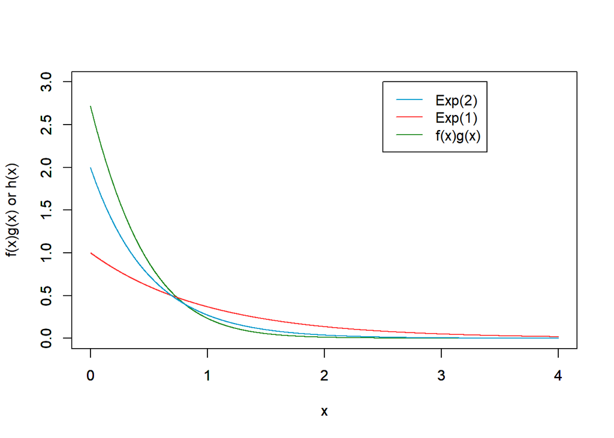

```r
x <- seq(0,4,0.001)
fg <- exp(-x)*exp(-x+cos(x))
h1 <- exp(-x)
h2 <- 2*exp(-2*x)
plot(x,fg,ylab="f(x)g(x) or h(x)",xlab="x",ylim=c(0,3),type="l",col="#228B22")
par(new=T)
plot(x,h1,ylab="",xlab="x",ylim=c(0,3),type="l",col="#FF3030")
par(new=T)
plot(x,h2,ylab="",xlab="x",ylim=c(0,3),type="l",col="#009ACD")
legend(x=2.5,y=3, c("Exp(2)","Exp(1)","f(x)g(x)"),lty=1,col=c("#009ACD","#FF3030","#228B22"))
```

#### h(x) -> Exp(1)

- $E(e ^{-X+cos(X)} )= \int _{0} ^{INF } {f(x)g(x)dx} = \int _{0} ^{INF } {e ^{-x+cos(x)} e ^{-x} dx} =a$
- ${\hat{a}} = \frac {1} {n} \sum _{i=1} ^{n} exp[-X _{i} +cos(X _{i} )]$

```r
set.seed(1)
X <- rexp(10000,1)
X1 <- exp(-X+cos(X))
(a <- mean(X1))
```

```
## [1] 1.169448
```

```r
var(X1)
```

```
## [1] 0.7766727
```

#### h(x) -> Exp(2)

- $E(e ^{-X+cos(X)} )= \int _{0} ^{INF } {f(x)g(x)dx} = \int _{0} ^{INF } {\frac {f(y)g(y)} {h(y)} h(y)dy} = \int _{0} ^{INF } {\frac {e ^{-y+cos(y)} e ^{-y}} {2e ^{-2y}} 2e ^{-2y} dy} =b$
- ${\hat{b}} = \frac {1} {n} \sum _{i=1} ^{n} \frac {1} {2} exp[cos(Y _{i} )]$

```r
set.seed(2)
Y <- rexp(10000,2)
Y1 <- exp(cos(Y))/2
(b <- mean(Y1))
```

```
## [1] 1.157739
```

```r
var(Y1)
```

```
## [1] 0.07216312
```

#### 결과적으로 h(x)의 분포가 Exp(2)일 때 분산이 크게 줄어듬을 확인 가능하다.

```r
var(X1) > var(Y1)
```

```
## [1] TRUE
```

## 2. f(x)를 density estimator로 추정 후 g(y)를 적절히 선택하여 분산을 줄일 수 있는지 확인 (R의 density 함수, kde package ?)

- $E _{g} [f(X)]= \int _{} ^{} {f(x)g(x)dx= \int _{} ^{} {\frac {f(x)g(x)} {h(x)} h(x)dx=E _{h} [\frac {f(X)g(X)} {h(X)} ]=m}}$
- $V _{1} ,V _{2} ,...,V _{n} -> h(v)$
- ${\hat{m}} = \frac {1}{n} \sum _{i=1} ^{n} \frac{f(V _{i} )g(V _{i} )} {h(V _{i} )}$
- 주어진 자료에 대한 분포가 주어지지 않은 경우에는 그 분포를 추정해야 함. (g(x)를 추정)
- 이후 추정된 분포 g(x)에 대한 특정값에서의 함수값을 구하는 것이 관건이라고 판단됨. 이 문제가 해결된다면 importance sampling에 대한 성능평가를 제대로 할 수 있음.

### 변수 time에 대한 density mean estimator 추정 (censoring 무시)

- g(x)만 추정하고 h(x)는 적절한 모수적 분포를 적용.

### Case1) transplant data

#### 주어진 데이터를 통해 변수 time에 대한 평균을 추정

```r
transplant <- read.csv("C:/Users/HSY/Desktop/transplant.csv",sep=",",header=T)
head(transplant,10)
```

```
##    group  time status
## 1      1 0.658      1
## 2      1 0.822      1
## 3      1 1.414      1
## 4      1 2.500      1
## 5      1 3.322      1
## 6      1 3.816      1
## 7      1 4.737      1
## 8      1 4.836      0
## 9      1 4.934      1
## 10     1 5.033      1
```

```r
dim(transplant)
```

```
## [1] 101   3
```

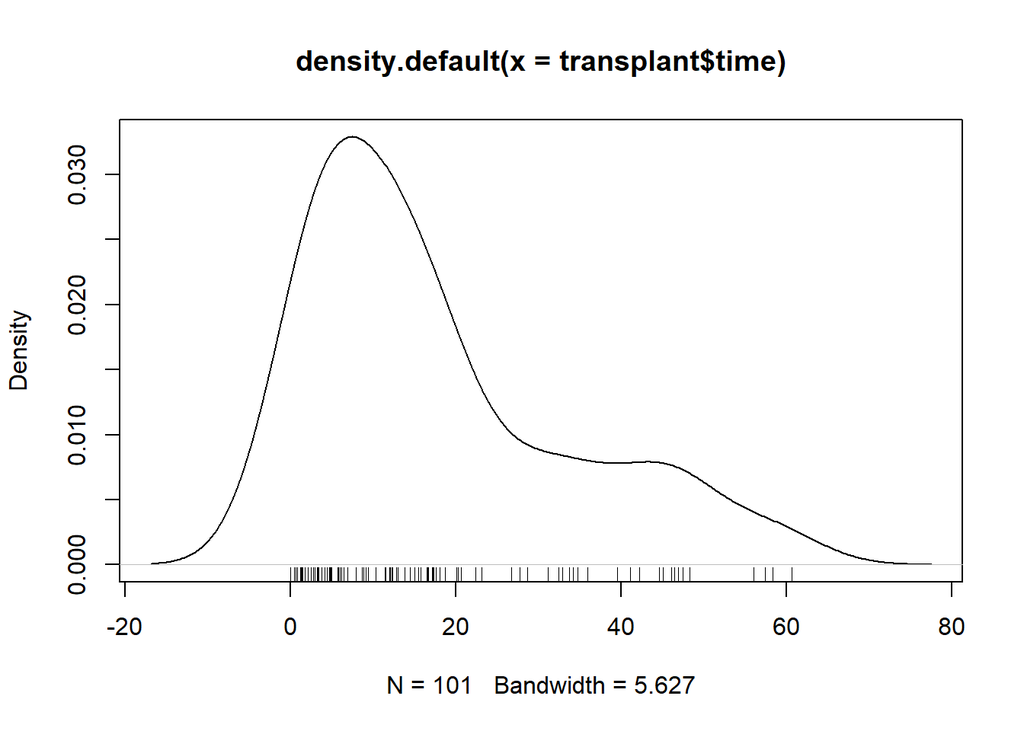

```r
plot(density(transplant$time))
rug(jitter(transplant$time))
```

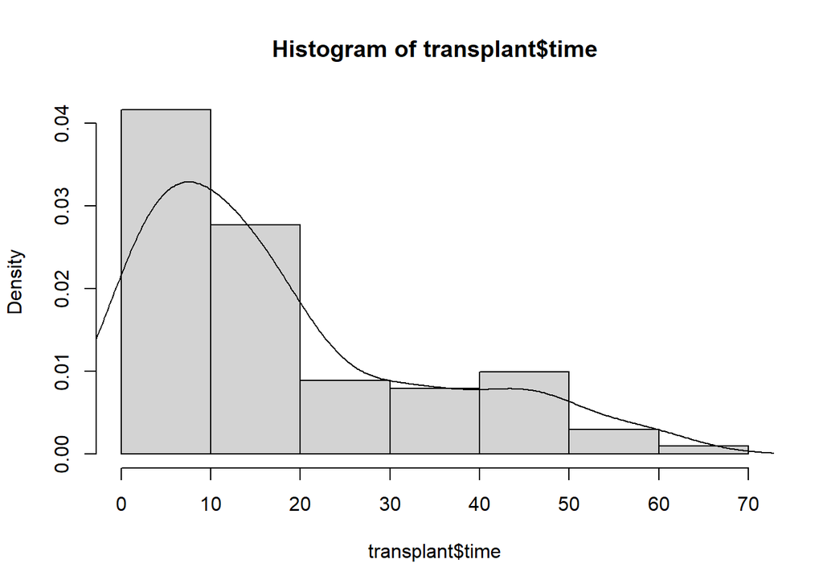

```r
hist(transplant$time,freq=FALSE)
lines(density(transplant$time))
```

```r
mean(transplant$time)
```

```
## [1] 17.6325
```

```r
var(transplant$time)
```

```
## [1] 252.5716
```

#### 2. 분포함수 h(x)를 감마분포로 가정하고 importance sampling 적용

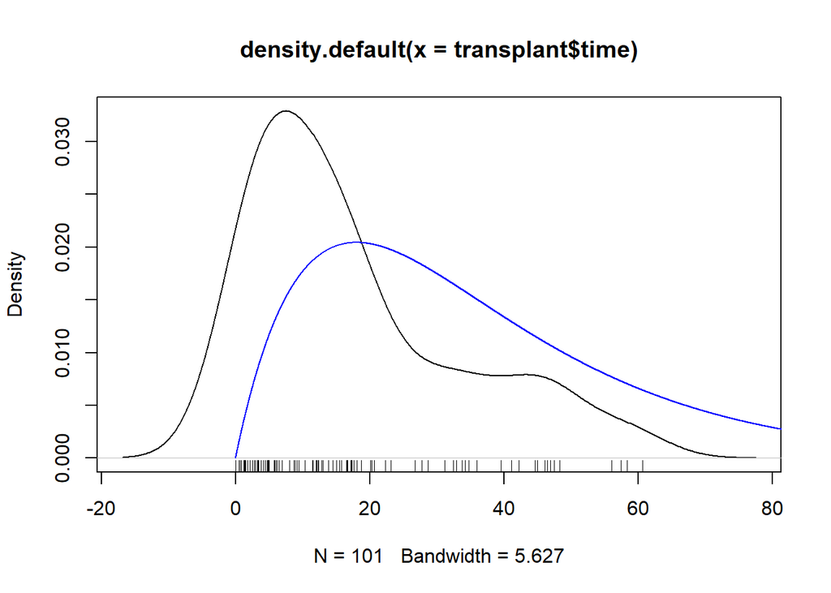

```r
plot(density(transplant$time))
rug(jitter(transplant$time))
x <- seq(0,100,0.001)
h <- dgamma(x,shape=2,scale=18)
lines(x,h,col="blue")
```

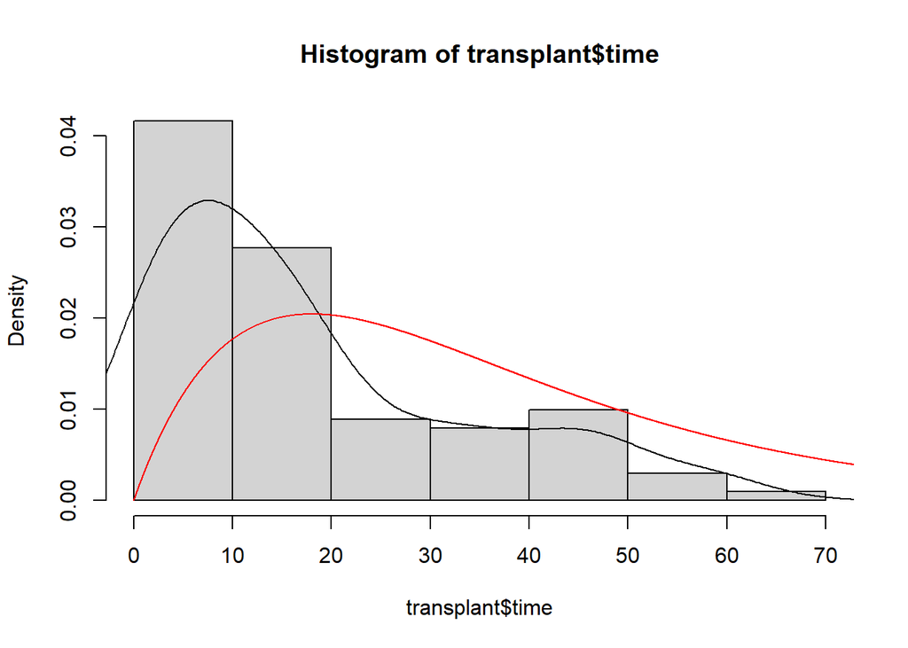

```r
hist(transplant$time,freq=FALSE)
lines(density(transplant$time))
x <- seq(0,100,0.001)
h <- dgamma(x,shape=2,scale=18)
lines(x,h,col="red")
```

```r
a <- density(transplant$time,n=101)
V <- sort(rgamma(101,shape=2,scale=18))
g <- a[["y"]]
h <- dgamma(V,shape=2,scale=18)
V1 <- (V*g)/h
mean(V1)
```

```
## [1] 14.16197
```

```r
var(V1)
```

```
## [1] 67.37204
```

#### 결과적으로 importance sampling을 적용 시 분산이 줄어듬을 확인 가능하다.

```r
mean(transplant$time) ; mean(V1)
```

```
## [1] 17.6325
```

```
## [1] 14.16197
```

```r
var(transplant$time) ; var(V1)
```

```
## [1] 252.5716
```

```
## [1] 67.37204
```

```r
var(transplant$time) > var(V1)
```

```
## [1] TRUE
```

### Case2) tonguecancer data

#### 주어진 데이터를 통해 변수 time에 대한 평균을 추정

```r
tonguecancer <- read.csv("C:/Users/HSY/Desktop/tonguecancer.csv",sep=",",header=T)
head(tonguecancer,10)
```

```
##    group time status
## 1      1    1      1
## 2      1    3      1
## 3      1    3      1
## 4      1    4      1
## 5      1   10      1
## 6      1   13      1
## 7      1   13      1
## 8      1   16      1
## 9      1   16      1
## 10     1   24      1
```

```r
dim(tonguecancer)
```

```
## [1] 80  3
```

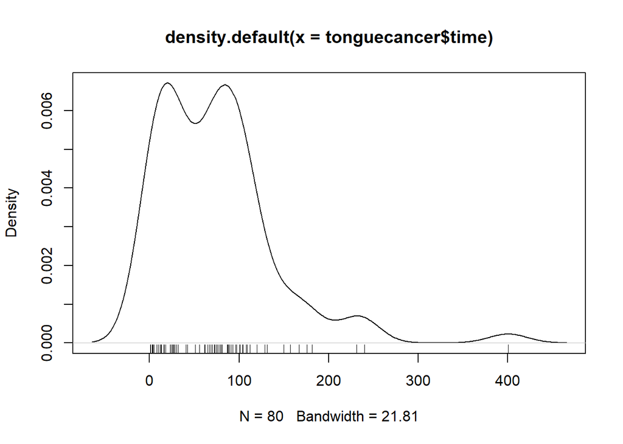

```r
plot(density(tonguecancer$time))
rug(jitter(tonguecancer$time))
```

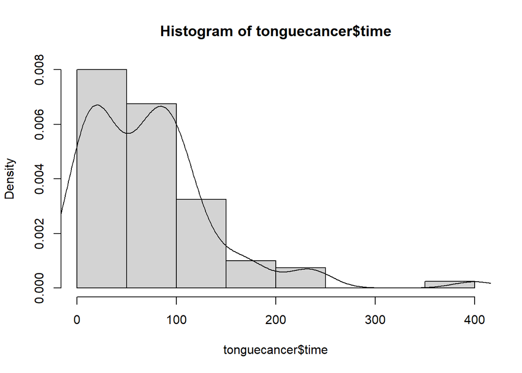

```r
hist(tonguecancer$time,freq=FALSE)
lines(density(tonguecancer$time))
```

```r
mean(tonguecancer$time)
```

```
## [1] 73.825
```

```r
var(tonguecancer$time)
```

```
## [1] 4524.323
```

#### 2. 분포함수 h(x)를 감마분포로 가정하고 importance sampling 적용

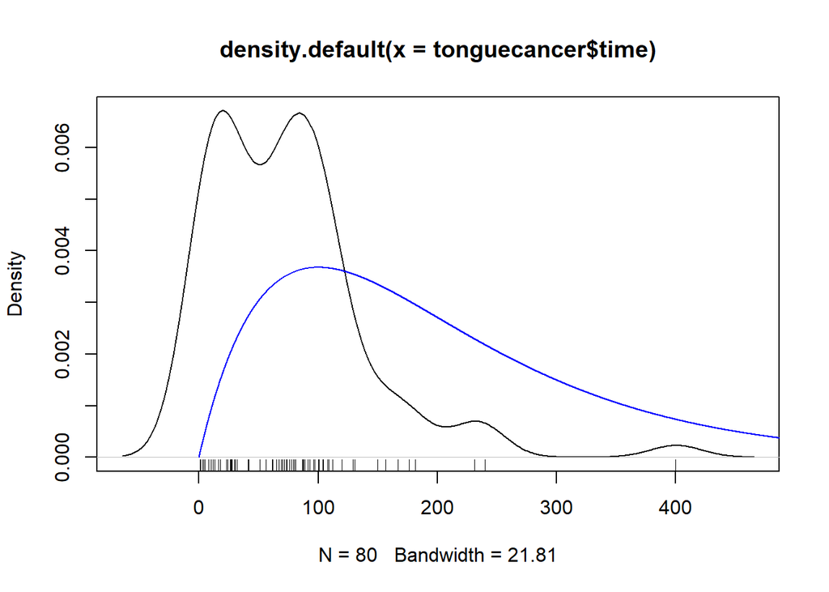

```r
plot(density(tonguecancer$time))
rug(jitter(tonguecancer$time))
x <- seq(0,1000,0.001)
h <- dgamma(x,shape=2,scale=100)
lines(x,h,col="blue")
```

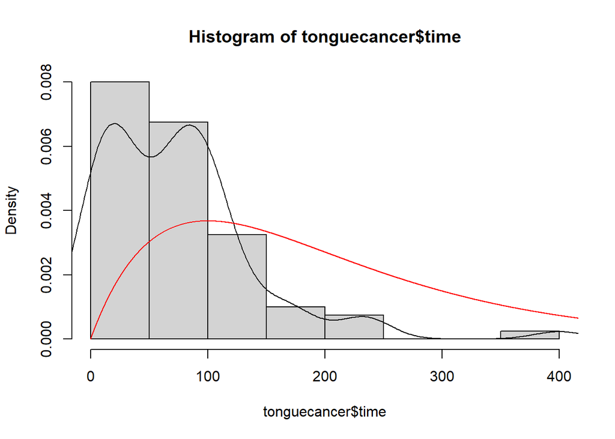

```r
hist(tonguecancer$time,freq=FALSE)
lines(density(tonguecancer$time))
x <- seq(0,1000,0.001)
h <- dgamma(x,shape=2,scale=100)
lines(x,h,col="red")
```

```r
a <- density(tonguecancer$time,n=80)
V <- sort(rgamma(80,shape=2,scale=100))
g <- a[["y"]]
h <- dgamma(V,shape=2,scale=100)
V1 <- (V*g)/h
mean(V1)
```

```
## [1] 67.12309
```

```r
var(V1)
```

```
## [1] 3568.305
```

#### 결과적으로 importance sampling을 적용 시 분산이 줄어듬을 확인 가능하다.

```r
mean(tonguecancer$time) ; mean(V1)
```

```
## [1] 73.825
```

```
## [1] 67.12309
```

```r
var(tonguecancer$time) ; var(V1)
```

```
## [1] 4524.323
```

```
## [1] 3568.305
```

```r
var(tonguecancer$time) > var(V1)
```

```
## [1] TRUE
```